# Summary of RF

Mafe Senosain

2020-10-23

# Example data set

```r
data <- makeExampleData()
class(data)
```

```
## [1] "list"
```

```r
class(data$view_1)
```

```
## [1] "matrix"
```

```r
data$view_1[1:5, 1:5]
```

```
##             sample_1     sample_2   sample_3   sample_4   sample_5
## feature1  1.97036382  0.156749643 -0.8339119  4.3039831 -2.3680635
## feature2  0.12949380  0.295122017  0.3893452 -0.2420038 -0.4558197
## feature3  2.29845349 -0.007488852 -0.7826086  2.9984549 -2.8218174
## feature4 -0.04168977 -0.373669623  0.2710207  0.1744561 -0.1090978
## feature5  1.53302169  0.363997524 -0.4456341  0.5895396 -2.3685844
```

```r
data$view_2[1:5, 1:5]
```

```
##            sample_1   sample_2   sample_3      sample_4   sample_5
## feature1  3.9272219  2.6214980 -1.7237387  1.5244425078 -1.8278073
## feature2 -0.2461691  0.2488576 -0.7565367 -0.0003582875  0.4310265
## feature3  0.3290696 -0.3900570  0.1155681  0.3079125432 -0.8536434
## feature4  1.3574695  2.0326427 -0.7687234 -0.3205364920 -1.4626499
## feature5 -0.2342700  0.2195615 -0.3021770 -0.0381526299 -0.3256409
```

```r
data$view_3[1:5, 1:5]
```

```
##            sample_1     sample_2     sample_3    sample_4    sample_5
## feature1 0.03186032  0.382429768 -0.007342999 -0.07023518  0.21271882
## feature2 1.13013888 -4.292384174  1.058629525 -0.17342268 -1.94835256
## feature3 0.17778893 -0.009158111 -0.027813636  0.19234110 -0.01921678
## feature4 0.03008354  0.348000446  0.507121821 -0.20550462  0.10390919
## feature5 0.74526542 -1.587324245  0.324974408 -0.63835871 -1.00297326
```

```r
summary(data$view_1[,1:10])
```

```
##     sample_1           sample_2           sample_3           sample_4
##  Min.   :-4.70960   Min.   :-2.76305   Min.   :-0.96755   Min.   :-4.2543
##  1st Qu.:-0.63783   1st Qu.:-0.73983   1st Qu.:-0.38786   1st Qu.:-1.0677
##  Median :-0.01881   Median :-0.06617   Median : 0.05628   Median :-0.1799
##  Mean   : 0.21502   Mean   :-0.17280   Mean   : 0.05255   Mean   :-0.2009
##  3rd Qu.: 1.05625   3rd Qu.: 0.30827   3rd Qu.: 0.39092   3rd Qu.: 0.5425
##  Max.   : 5.20282   Max.   : 2.12154   Max.   : 1.69729   Max.   : 4.3040
##     sample_5          sample_6          sample_7           sample_8
##  Min.   :-5.0120   Min.   :-1.9926   Min.   :-3.05154   Min.   :-2.0116
##  1st Qu.:-1.3807   1st Qu.:-0.4653   1st Qu.:-0.43355   1st Qu.:-0.5092
##  Median :-0.5572   Median : 0.1294   Median : 0.02437   Median :-0.1025
##  Mean   :-0.4635   Mean   : 0.1433   Mean   : 0.04125   Mean   :-0.0741
##  3rd Qu.: 0.5059   3rd Qu.: 0.8490   3rd Qu.: 0.56623   3rd Qu.: 0.3652
##  Max.   : 3.9690   Max.   : 2.6686   Max.   : 3.24816   Max.   : 1.7765
##     sample_9          sample_10
##  Min.   :-2.71316   Min.   :-4.45394
##  1st Qu.:-0.45998   1st Qu.:-0.79073
##  Median : 0.04655   Median :-0.09981
##  Mean   : 0.01494   Mean   :-0.11822
##  3rd Qu.: 0.51905   3rd Qu.: 0.45261
##  Max.   : 2.19558   Max.   : 4.27651
```

```r
set.seed(1234)
MOFAobject <- createMOFAobject(data)
```

```
## Creating MOFA object from list of matrices,
##  please make sure that samples are columns and features are rows...
```

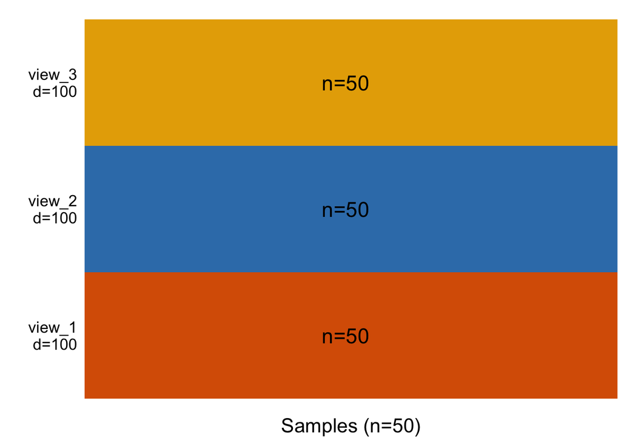

```r
plotDataOverview(MOFAobject)
```

## Prepare MOFA: Set the training and model options

```r
TrainOptions <- getDefaultTrainOptions()
ModelOptions <- getDefaultModelOptions(MOFAobject)
DataOptions <- getDefaultDataOptions()

TrainOptions$DropFactorThreshold <- 0.01
```

## Run MOFA

```r
n_inits <- 3
MOFAlist <- lapply(seq_len(n_inits), function(it) {

  TrainOptions$seed <- 2018 + it

  MOFAobject <- prepareMOFA(MOFAobject,
                            DataOptions = DataOptions,
                            ModelOptions = ModelOptions,
                            TrainOptions = TrainOptions
)

  runMOFA(MOFAobject)
})
```

```
## Checking data options...
```

```
## Checking training options...
```

```
## Checking model options...
```

```
## [1] "No output file provided, using a temporary file..."
```

```
## Checking data options...
```

```
## Checking training options...
```

```
## Checking model options...
```

```
## [1] "No output file provided, using a temporary file..."
```

```
## Checking data options...
```

```
## Checking training options...
```

```
## Checking model options...
```

```
## [1] "No output file provided, using a temporary file..."
```

## Compare different random inits and select the best model

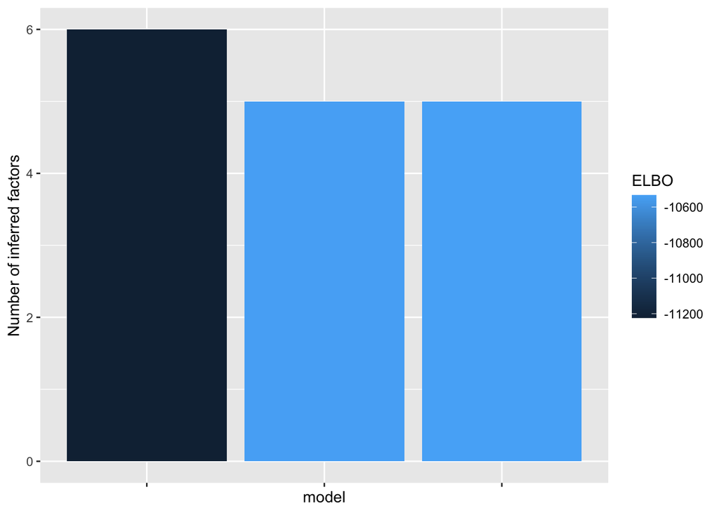

```r
compareModels(MOFAlist)
```

With compareFactors we can get an overview of how robust the factors are between different model instances.

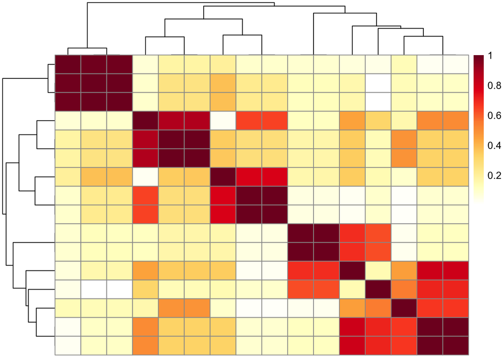

```r
compareFactors(MOFAlist)
```

For down-stream analyses we recommned to choose the model with the best ELBO value as is done by selectModel.

```r
MOFAobject <- selectModel(MOFAlist, plotit = FALSE)
MOFAobject
```

```
## Trained MOFA model with the following characteristics:
##   Number of views: 3
##  View names: view_1 view_2 view_3
##   Number of features per view: 100 100 100
##   Number of samples: 50
##   Number of factors: 5
```

## Downstream analyses

On the trained MOFAobject we can now start looking into the inferred factors, its weights etc. Here the data was generated using five factors, whose activity patterns we can recover using plotVarianceExplained.

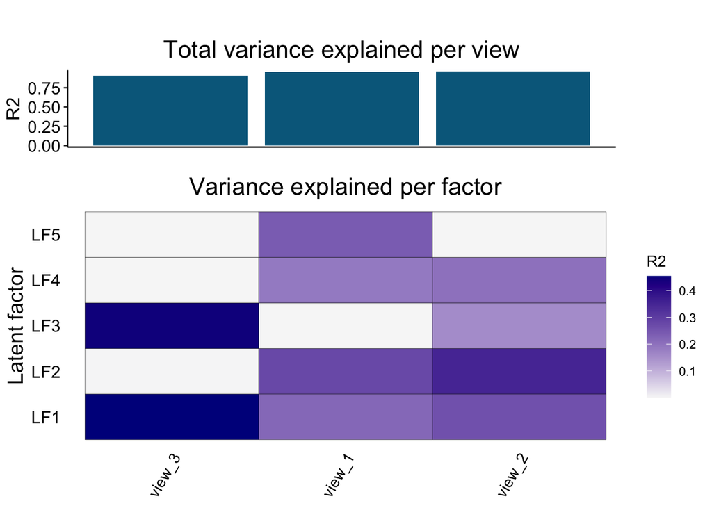

```r
plotVarianceExplained(MOFAobject)
```

# Mafe’s data (CyTOF, RNA Seq, WES)

## Preprocessing data

```r
mofa_data <- list('CyTOF_exp'=CyTOF_exp,
                  'CyTOF_prcnt'=CyTOF_prcnt,
                  'RNA_topgenes'=RNA_top12K_E,
                  'RNA_xcell'=RNA_xcell,
                  'mutation'=mut_dt)
set.seed(1234)
MOFAobject <- createMOFAobject(mofa_data)
```

```
## Creating MOFA object from list of matrices,
##  please make sure that samples are columns and features are rows...
```

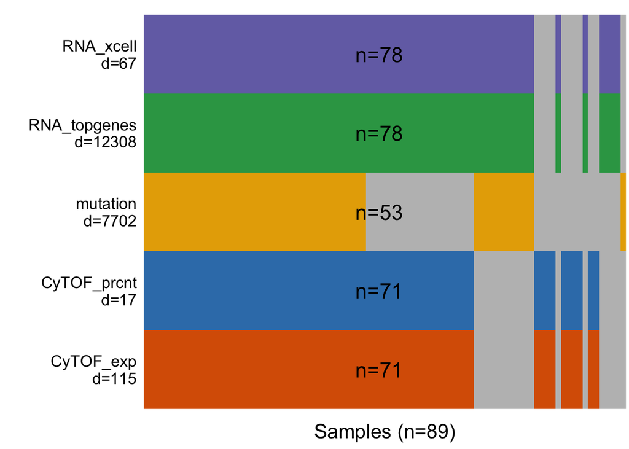

```r
plotDataOverview(MOFAobject)
```

## Prepare MOFA: Set the training and model options

The most important options the user needs to define are:

scaleViews: logical indicating whether to scale views to have unit variance. As long as the scale of the different data sets is not too high, this is not required. Default is FALSE.

removeIncompleteSamples: logical indicating whether to remove samples that are not profiled in all omics. The model can cope with missing assays, so this option is not required. Default is FALSE.

### Data options

```r
DataOptions <- getDefaultDataOptions()
DataOptions
```

```
## $scaleViews
## [1] FALSE
##
## $removeIncompleteSamples
## [1] FALSE
```

### Model options

Next, we define model options. The most important are:

numFactors: number of factors (default is 0.5 times the number of samples). By default, the model will only remove a factor if it explains exactly zero variance in the data. You can increase this threshold on minimum variance explained by setting TrainOptions$dropFactorThreshold to a value higher than zero.

likelihoods: likelihood for each view. Usually we recommend gaussian for continuous data, bernoulli for binary data and poisson for count data. By default, the model tries to guess it from the data.

sparsity: do you want to use sparsity? This makes the interpretation easier so it is recommended (Default is TRUE).

```r
ModelOptions <- getDefaultModelOptions(MOFAobject)
ModelOptions
```

```
## $likelihood
##    CyTOF_exp  CyTOF_prcnt RNA_topgenes    RNA_xcell     mutation
##   "gaussian"   "gaussian"   "gaussian"   "gaussian"  "bernoulli"
##
## $numFactors
## [1] 45
##
## $sparsity
## [1] TRUE
```

### Training options

Next, we define training options. The most important are:

maxiter: maximum number of iterations. Ideally set it large enough and use the convergence criterion TrainOptions$tolerance.

tolerance: convergence threshold based on change in the evidence lower bound. For an exploratory run you can use a value between 1.0 and 0.1, but for a “final” model we recommend a value of 0.01.

DropFactorThreshold: hyperparameter to automatically learn the number of factors based on a minimum variance explained criteria. Factors explaining less than DropFactorThreshold fraction of variation in all views will be removed. For example, a value of 0.01 means that factors that explain less than 1% of variance in all views will be discarded. By default this it zero, meaning that all factors are kept unless they explain no variance at all.

```r
TrainOptions <- getDefaultTrainOptions()

# Automatically drop factors that explain less than 2% of variance in all omics
TrainOptions$DropFactorThreshold <- 0.02

TrainOptions$seed <- 2017

TrainOptions
```

```
## $maxiter
## [1] 5000
##
## $tolerance
## [1] 0.1
##
## $DropFactorThreshold
## [1] 0.02
##
## $verbose
## [1] FALSE
##
## $seed
## [1] 2017
```

## Prepare MOFA

prepareMOFA internally performs a set of sanity checks and fills the DataOptions, TrainOptions and ModelOptions slots of the MOFAobject

```r
MOFAobject <- prepareMOFA(
  MOFAobject,
  DataOptions = DataOptions,
  ModelOptions = ModelOptions,
  TrainOptions = TrainOptions
)
```

```
## Checking data options...
```

```
## Checking training options...
```

```
## Checking model options...
```

## Run MOFA

```r
MOFAobject <- runMOFA(MOFAobject)
```

```
## [1] "No output file provided, using a temporary file..."
```

## Analyse trained MOFA model

Disentangling the heterogeneity: calculation of variance explained by each factor in each view

```r
# Calculate the variance explained (R2) per factor in each view
r2 <- calculateVarianceExplained(MOFAobject)
r2$R2Total
```

```
##    CyTOF_exp  CyTOF_prcnt RNA_topgenes    RNA_xcell     mutation
## 0.1419104781 0.0851983495 0.4302670850 0.3806609755 0.0003080671
```

```r
# Variance explained by each factor in each view
head(r2$R2PerFactor)
```

```
##        CyTOF_exp  CyTOF_prcnt RNA_topgenes   RNA_xcell     mutation
## LF1 0.0020015719 0.0065047496   0.06147975 0.164004687 3.166473e-05
## LF2 0.0093917152 0.0035743468   0.10619509 0.086885267 9.529527e-05
## LF3 0.1070704924 0.0405874661   0.03522311 0.002476424 1.289023e-05
## LF4 0.0001620447 0.0069699196   0.07927646 0.066290741 2.400116e-05
## LF5 0.0236181216 0.0268208183   0.02509732 0.024288234 2.878750e-05
## LF6 0.0000246668 0.0004258643   0.02913822 0.021228741 1.795880e-05
```

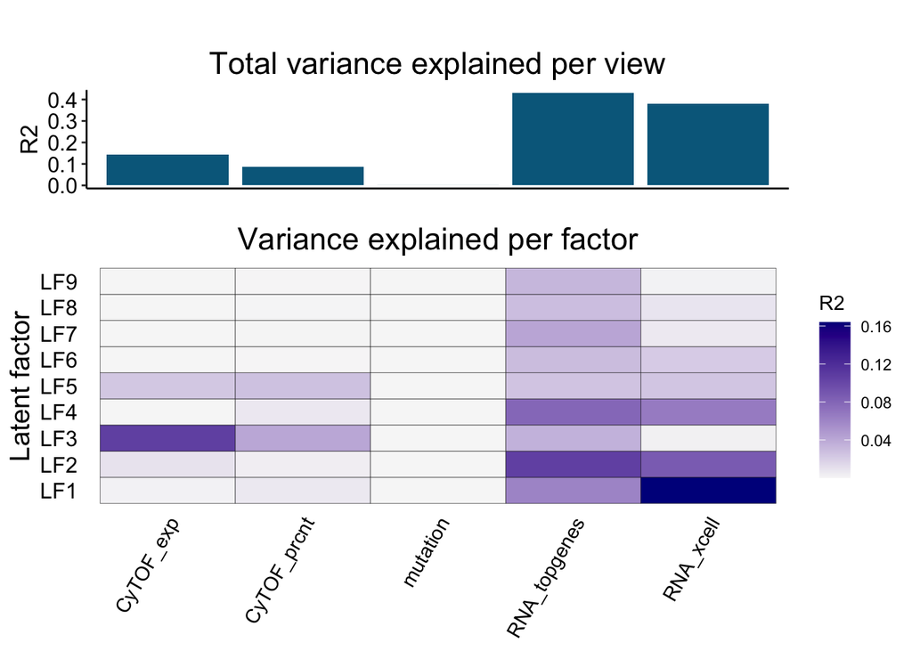

```r
# Plot it
plotVarianceExplained(MOFAobject)
```

### Characterization of individual factors

To get an overview of the weights across all factors in a given view you can use the plotWeightsHeatmap function.

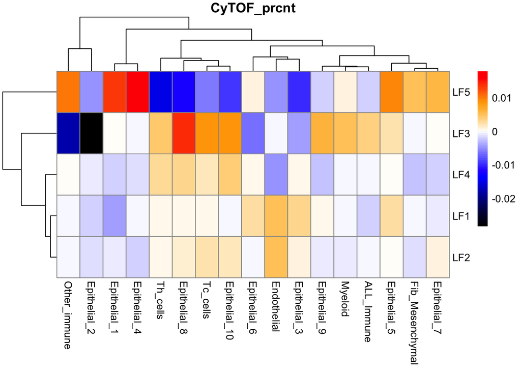

```r
plotWeightsHeatmap(
  MOFAobject,
  view = "CyTOF_prcnt",
  factors = 1:5,
  show_colnames = T, main = 'CyTOF_prcnt'
)
```

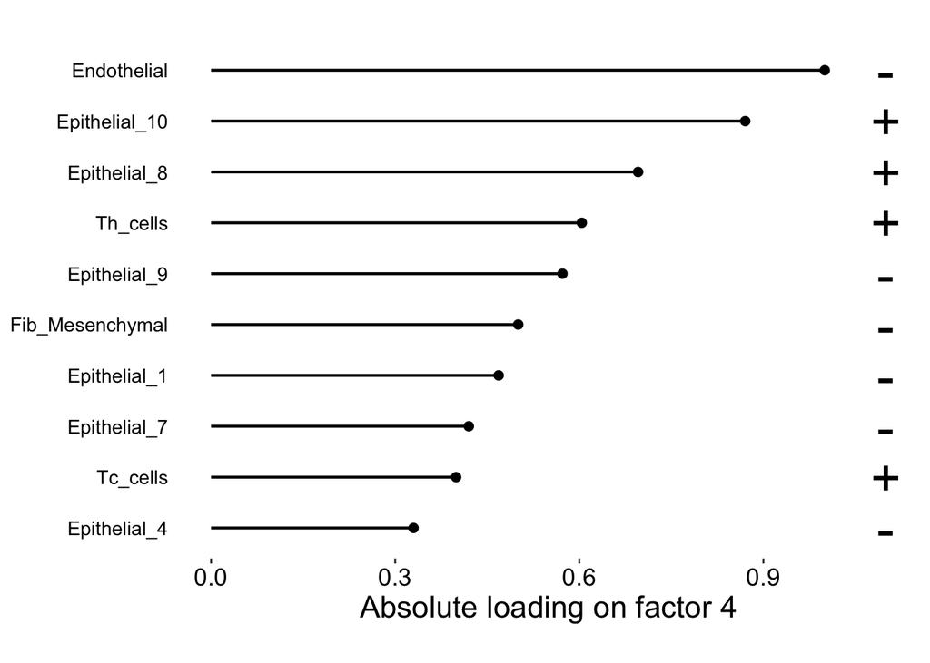

```r
plotTopWeights(
  MOFAobject,
  view="CyTOF_prcnt",
  factor=4
)
```

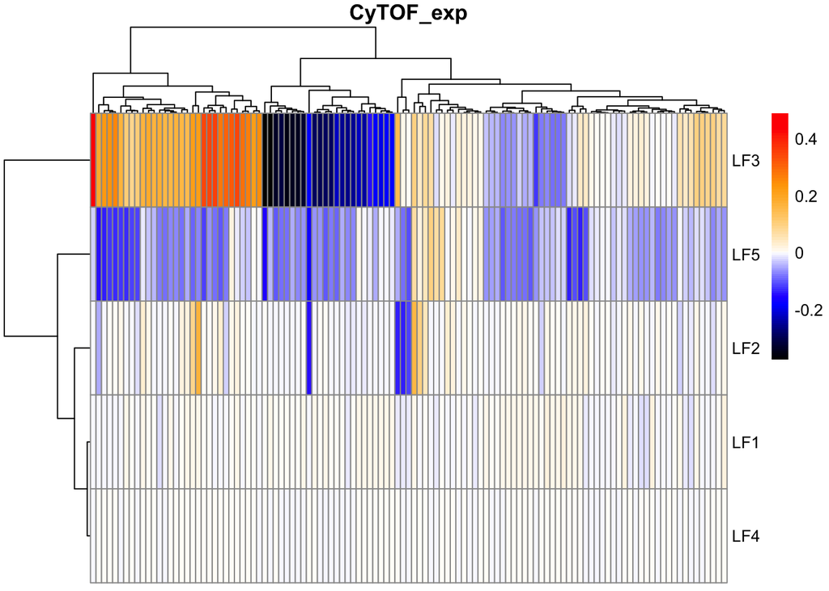

```r
plotWeightsHeatmap(
  MOFAobject,
  view = "CyTOF_exp",
  factors = 1:5,
  show_colnames = FALSE, main = 'CyTOF_exp'
)
```

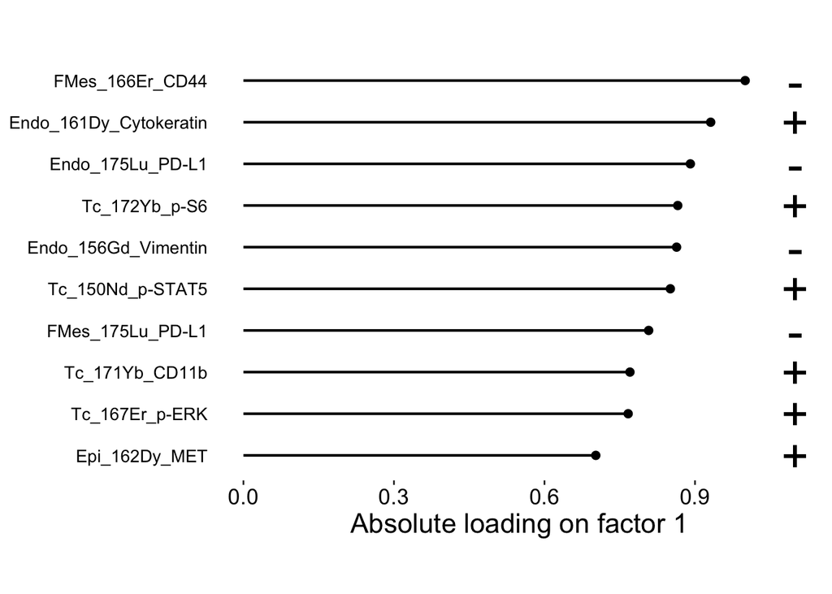

```r
plotTopWeights(
  MOFAobject,
  view="CyTOF_exp",
  factor=1
)
```

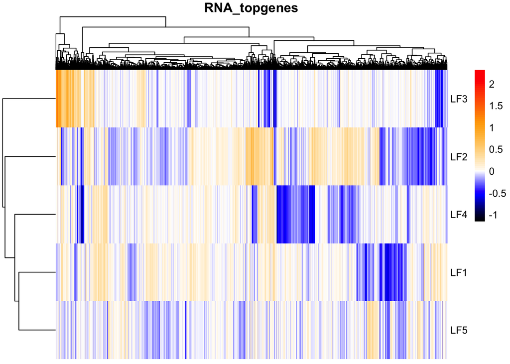

```r
plotWeightsHeatmap(
  MOFAobject,
  view = "RNA_topgenes",
  factors = 1:5,
  show_colnames = FALSE, main = 'RNA_topgenes'
)
```

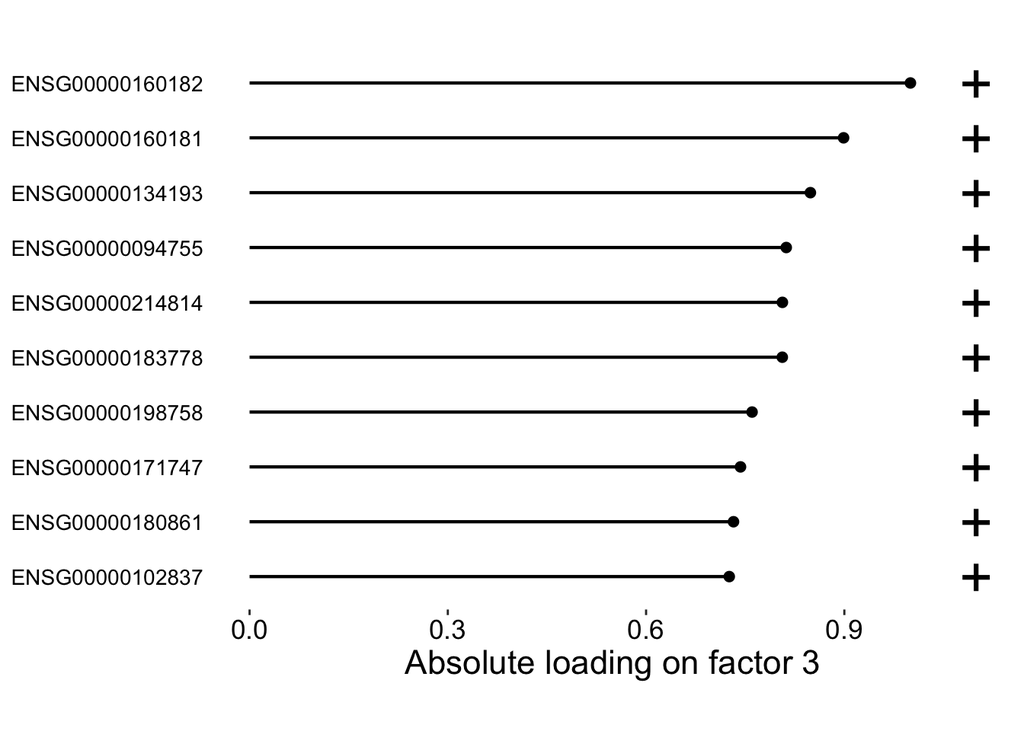

```r
plotTopWeights(
  MOFAobject,
  view="RNA_topgenes",
  factor=3
)
```

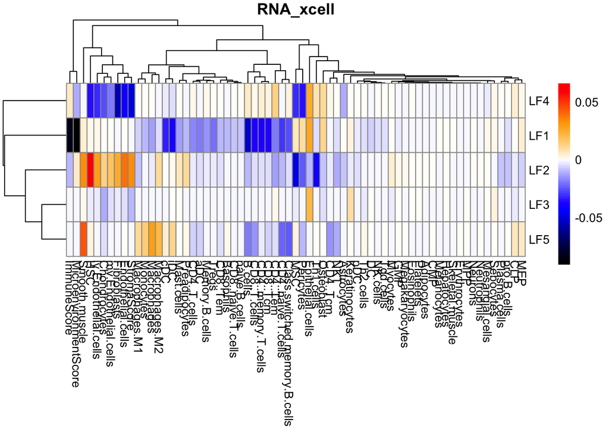

```r
plotWeightsHeatmap(
  MOFAobject,
  view = "RNA_xcell",
  factors = 1:5,
  show_colnames = T, main = 'RNA_xcell'
)
```

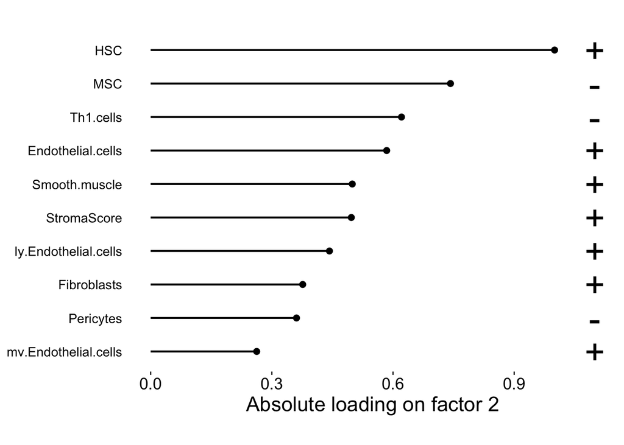

```r
plotTopWeights(
  MOFAobject,
  view="RNA_xcell",
  factor=2
)
```

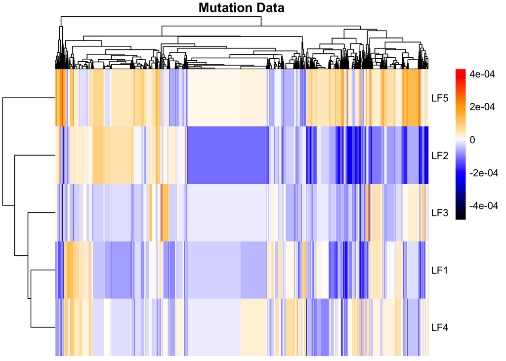

```r
plotWeightsHeatmap(
  MOFAobject,
  view = "mutation",
  factors = 1:5,
  show_colnames = F, main = 'Mutation Data'
)
```

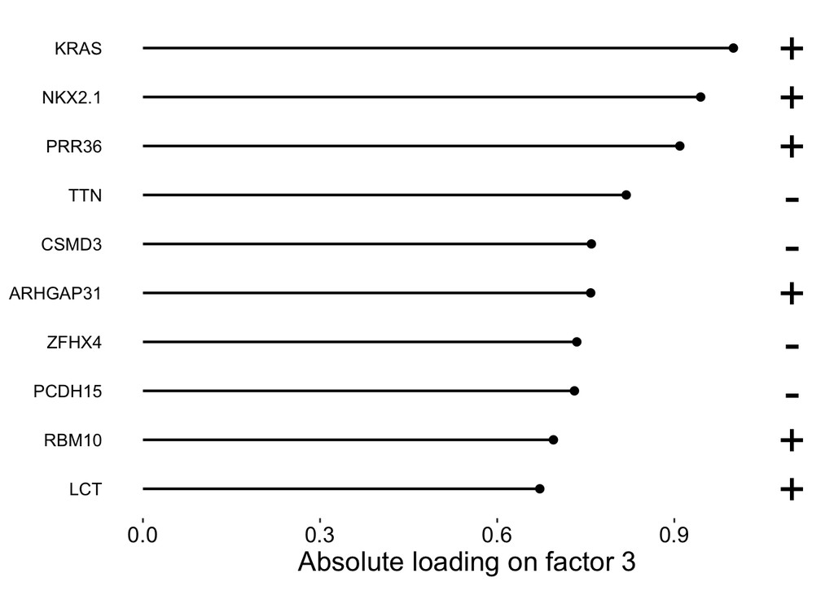

```r
plotTopWeights(
  MOFAobject,
  view="mutation",
  factor=3
)
```

### Feature set enrichment analysis in the active views

```r
# Load reactome annotations
data("reactomeGS") # binary matrix with feature sets in rows and features in columns

# perform enrichment analysis
gsea <- runEnrichmentAnalysis(
  MOFAobject,
  view = "RNA_topgenes",
  feature.sets = reactomeGS,
  alpha = 0.01
)
```

```
## Doing Feature Set Enrichment Analysis with the following options...
```

```
## View: RNA_topgenes
```

```
## Factors: LF1 LF2 LF3 LF4 LF5 LF6 LF7 LF8 LF9
```

```
## Number of feature sets: 640
```

```
## Local statistic: loading
```

```
## Transformation: abs.value
```

```
## Global statistic: mean.diff
```

```
## Statistical test: parametric
```

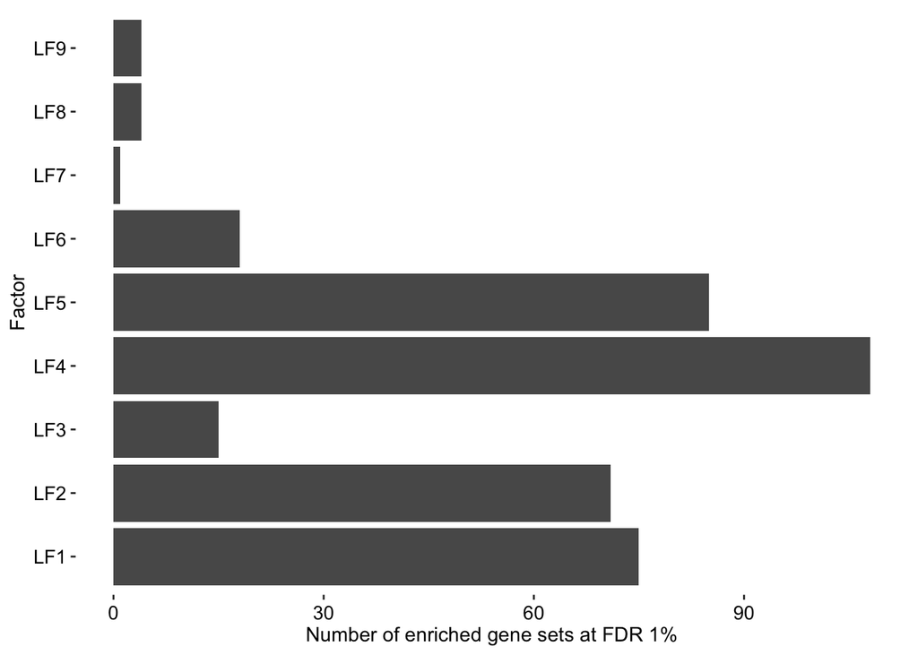

```r
plotEnrichmentBars(gsea, alpha=0.01)
```

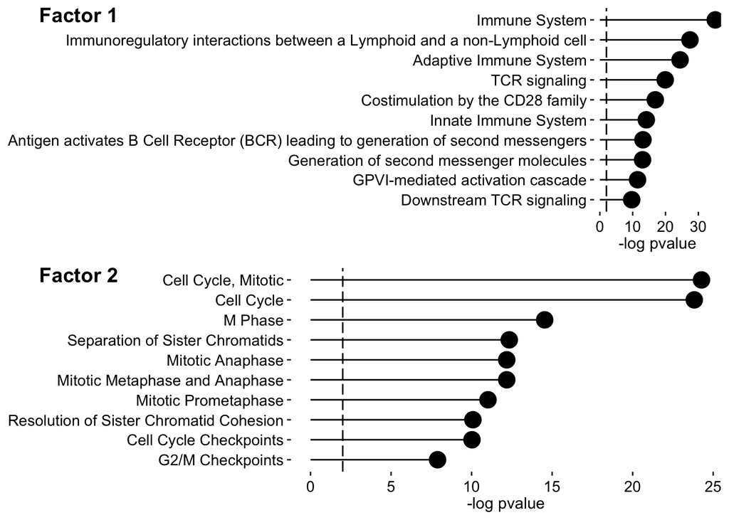

```r
interestingFactors <- 1:5

fseaplots <- lapply(interestingFactors, function(factor) {
  plotEnrichment(
    MOFAobject,
    gsea,
    factor = factor,
    alpha = 0.01,
    max.pathways = 10 # The top number of pathways to display
  )
})

cowplot::plot_grid(fseaplots[[1]], fseaplots[[2]],
                   ncol = 1, labels = paste("Factor", interestingFactors))
```

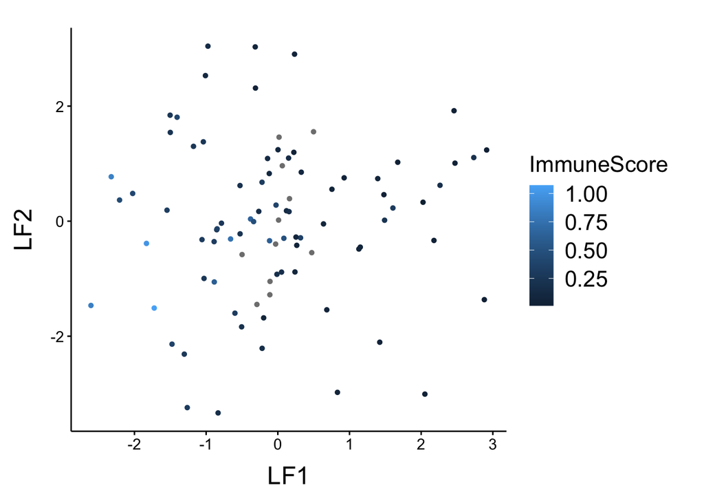

```r
plotFactorScatter(
  MOFAobject,
  factors = 1:2,
  color_by = "ImmuneScore"      # color by the IGHV values that are part of the training data
  #shape_by = "trisomy12"  # shape by the trisomy12 values that are part of the training data
)
```

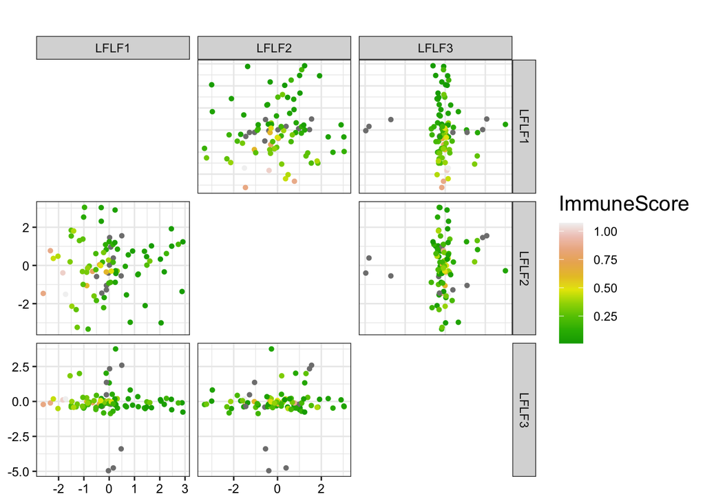

```r
plotFactorScatters(
  MOFAobject,
  factors = 1:3,
  color_by = "ImmuneScore"
)
```

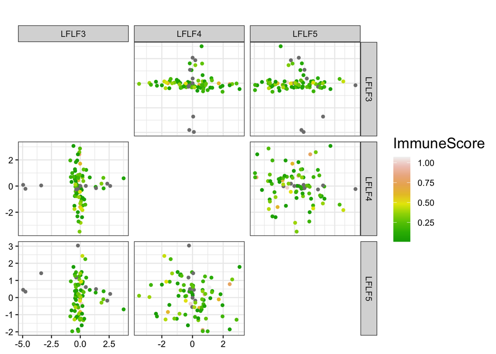

```r
plotFactorScatters(
  MOFAobject,
  factors = 3:5,
  color_by = "ImmuneScore"
)
```

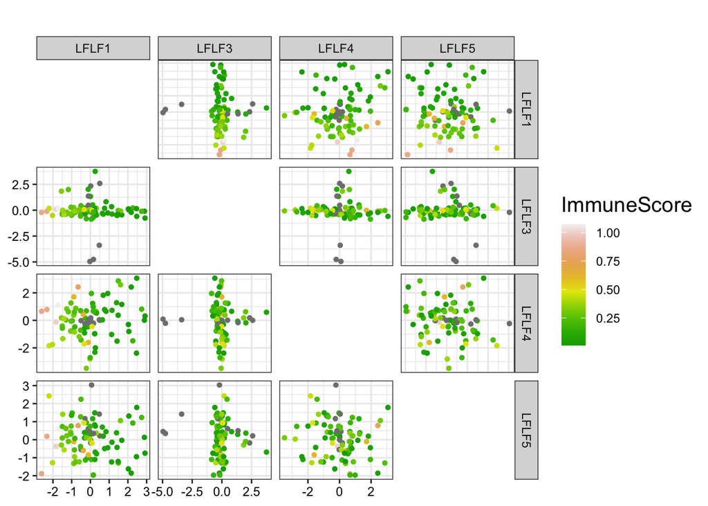

```r
plotFactorScatters(
  MOFAobject,
  factors = c(1, 3:5),
  color_by = "ImmuneScore"
)
```